# Association Rules

Cesc

11.24

## 准备工作

```r
setwd('D://R')        # 默认路径
library(arules)       # 程序包：关联规则
library(arulesViz)    # 程序包：规则可视化
library(RColorBrewer) # 程序包：调色盘
```

## 读取数据集

```r
groceries <- read.transactions("groceries.csv", format="basket", sep=",")
gro <- read.csv('groceries.csv', header = F)
head(gro) # 查看数据的储存格式
```

```
##                 V1                  V2             V3
## 1     citrus fruit semi-finished bread      margarine
## 2   tropical fruit              yogurt         coffee
## 3       whole milk
## 4        pip fruit              yogurt   cream cheese
## 5 other vegetables          whole milk condensed milk
## 6       whole milk              butter         yogurt
##                         V4
## 1              ready soups
## 2
## 3
## 4             meat spreads
## 5 long life bakery product
## 6                     rice
```

数据的储存格式可以如上所示，每一行表示一次观测（比如看一期财报），内容是修改过的items（比如营业收入等）。在txt中，每一项item用逗号隔开；在Excel中，每一项item占一列。此外，记载的顺序不作要求，每一次观测到的item个数不作要求。

## 数据探查

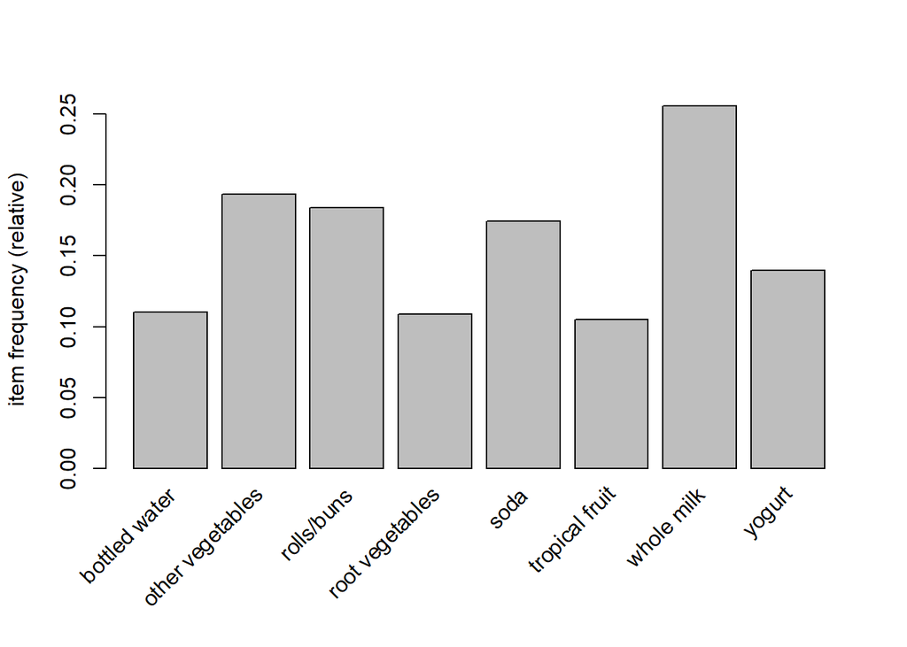

```r
itemFrequencyPlot(groceries, support=0.1)
```

该柱状图展示了每一项出现的频次，也可以理解为概率。例如，如果观察了100期财报，其中营业收入修改过的有36次，则item frequency（频次）为36%。

## 模型建立

```r
# 代入关联规则模型
groceryrules <- apriori(groceries, parameter = list(support = 0.006, confidence = 0.25, minlen = 2))
```

```r
# 查看结果
ordered_groceryrules <- sort(groceryrules, by="lift") # 按照提升度排序
inspect(ordered_groceryrules[1:5])                    # 报告提升度前5的规则
```

```
##     lhs                   rhs                      support confidence     lift count
## [1] {herbs}            => {root vegetables}    0.007015760  0.4312500 3.956477    69
## [2] {berries}          => {whipped/sour cream} 0.009049314  0.2721713 3.796886    89
## [3] {other vegetables,
##      tropical fruit,
##      whole milk}       => {root vegetables}    0.007015760  0.4107143 3.768074    69
## [4] {beef,
##      other vegetables} => {root vegetables}    0.007930859  0.4020619 3.688692    78
## [5] {other vegetables,
##      tropical fruit}   => {pip fruit}          0.009456024  0.2634561 3.482649    93
```

lhs理解为关联规则的“因”，rhs理解为“果”，属于此两列的内容是项目名称(item)。support表示前两列同时出现的频率，confidence表示有“因”在的前提下，“果”出现的频率。lift的计算较为复杂，通俗地讲，该指标直接刻画了项目的因果关系，是最重要的指标，该指标的值越大，表明前两列的关联关系越深。count表明前两列所有的项目同时出现的次数（计数指标）。

用第一行举例，herbs和root vegetables是两个项目的名称，可以类比为财报中的两项指标。count=69，support=0.007表面了在整个表中，这两项同时出现的行数有69行，即69次观测，占比为0.7%。confidence=0.431表明了在herbs出现的情况下，root vegetables出现的频数占比为43.1%，这个值可以理解为概率。lift（提升度）是表明关联关系的统计量，该值大于3的时候我们认为该项关联关系是有价值的。

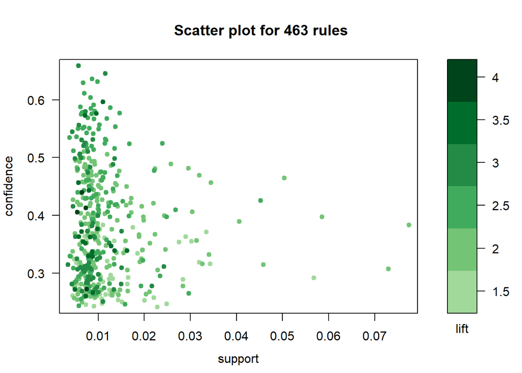

```r
plot(groceryrules, control=list(jitter=2, col = rev(brewer.pal(9, "Greens")[4:9])), shading = "lift")
```

## 规则可视化

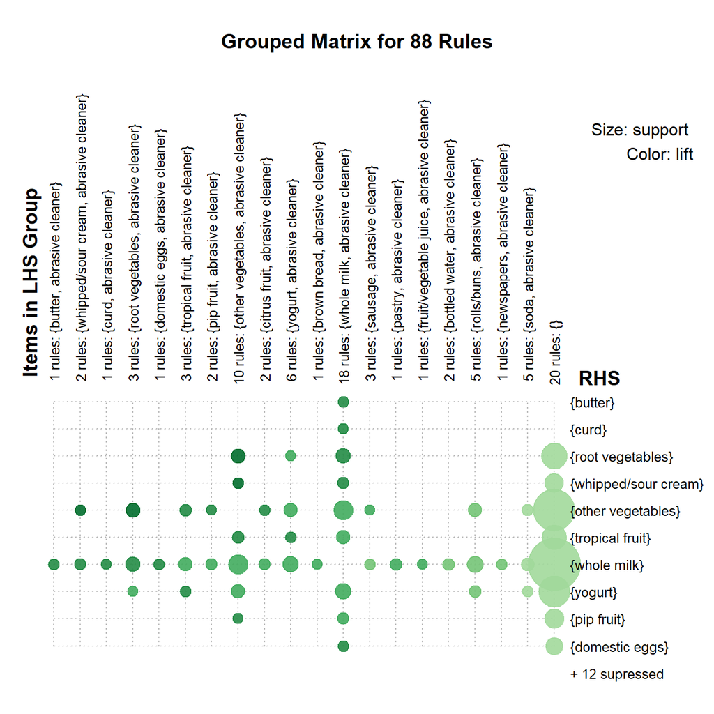

```r
# 避免图过于繁杂，我们提升规则的阈值。
second.rules <- apriori(groceries, parameter = list(support = 0.025, confidence = 0.06))

plot(second.rules, method="grouped",control=list(col = rev(brewer.pal(9, "Greens")[4:9])))
```

上轴LHS表示规则的因，右轴RHS表示规则的果。气泡的大小表示支持度的相对大小，颜色代表提升度的相对大小。

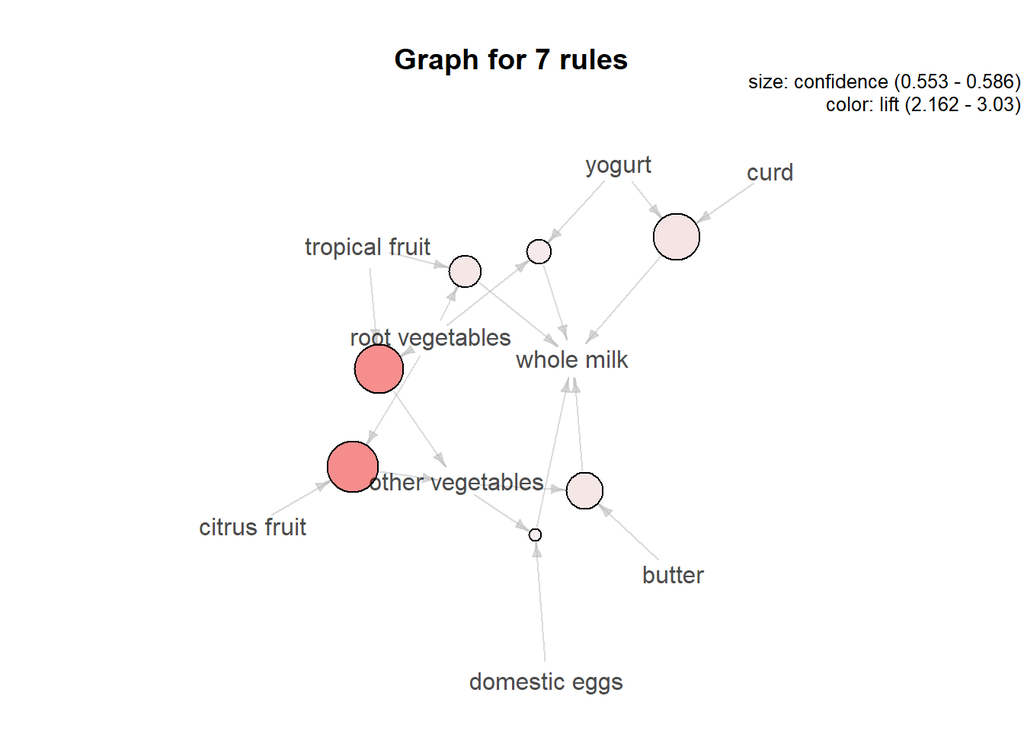

```r
# 取支持度与置信度都较高的规则。
top.vegie.rules <- apriori(groceries, parameter = list(support = 0.01, confidence = 0.55, minlen = 2))
# 网络可视化。
plot(top.vegie.rules, measure="confidence", method="graph", control=list(type="items"), shading = "lift")
```

通过网络图的方式传达关联规则的信息，箭头的指向反映规则的因果关系。圆圈大小反映置信度，深浅表示提升度。

## 总结

> 要理解关联规则模型，需要理解三个指标，支持度：support，置信度：confidence，提升度：lift。这三个指标都能从不同角度反映关联关系的深浅，普遍认为提升度是最重要的指标，置信度和支持度其次。

> 我们所说的关联关系，就是字面意义上的“关联”。比如有三个项目{a,b,c}，如果我们的规则中有一条是{a,b}->{c}，并且该规则的三个指标的值都较大，那么我们应该重视这条规则，它告诉我们，当a和b都出现时，出现c的概率就会比较大。